# Yahoo FTSE-100

Introduction: The Financial Times Stock Exchange 100 Index, also called the FTSE 100 Index, is a share index of the 100 companies listed on the London Stock Exchange with the highest market capitalization. The index is maintained by the FTSE Group, a now wholly-owned subsidiary of the London Stock Exchange, which originated as a joint venture between the Financial Times and the London Stock Exchange. In this analysis, the evaluation of stock performance will be done based on their last 20 years’ annual returns and trends. By using this FTSE 100 data from yahoo I will analyze the volatility, volume, adjusted price of the stock and also will analyze the uncertainty in the stock market. First I will merge the FTSE annual data with the annual return data for all the company stock present in the list, then I will calculate the volatility and excessive return for the last 20 years for all the stock and will identify which stock showing the highest volatility and annual return, apart from that I will also analyze the volume of each company share and their trend.

#Task - 1

#First 6 rows of FTSE100 Constituents dataset.

```
## # A tibble: 6 x 2
##   company        ticker
##   <chr>          <chr>
## 1 3I GRP.        III.L
## 2 A.B.FOOD       ABF.L
## 3 ADMIRAL GRP    ADM.L
## 4 ANGLO AMERICAN AAL.L
## 5 ANTOFAGASTA    ANTO.L
## 6 ASHTEAD GRP.   AHT.L
```

#First 6 rows of Myreturns dataset.

```
##   ticker ref.date     volume price.open price.high price.low price.close
## 1  AAL.L 2000/1/3 2044229744   1130.495   1201.923  630.4945    1013.736
## 2  AAL.L 2001/1/1 2443244237   1013.736   1408.791  714.2857    1143.956
## 3  AAL.L 2002/1/1 1388244758   1143.956   1427.033  751.6483    1013.736
## 4  AAL.L 2003/1/1  749609875   1013.736   1426.374  904.9450    1326.374
## 5  AAL.L 2004/1/1  345867477   1326.374   1572.055 1148.3516    1353.846
## 6  AAL.L 2005/1/3  304706169   1353.846   2185.714 1229.6703    2174.725
##   price.adjusted ret.adjusted.prices ret.closing.prices
## 1       558.6298                  NA                 NA
## 2       652.7030          0.16839998         0.12845536
## 3       597.0835         -0.08521411        -0.11383291
## 4       814.8405          0.36470112         0.30840119
## 5       844.0920          0.03589839         0.02071242
## 6      1398.9734          0.65737079         0.60633114
```

#First 6 rows of FTSE100 dataset.

```
##   ref.date FTSE.volume FTSE.price.open FTSE.price.high FTSE.price.low
## 1 3/1/2000 2.43909e+11          6930.2          6930.2         5915.2
## 2 1/1/2001 3.20735e+11          6222.5          6360.3         4219.8
## 3 1/1/2002 3.90104e+11          5217.4          5362.3         3609.9
## 4 1/1/2003 4.16044e+11          3940.4          4491.8         3277.5
## 5 1/1/2004 4.15893e+11          4476.9          4826.2         4283.0
## 6 3/1/2005 3.95070e+11          4814.3          5647.2         4765.4
##   FTSE.price.close FTSE.price.adjusted FTSE.ret.adjusted.prices
## 1           6222.5              6222.5                       NA
## 2           5217.4              5217.4              -0.16152673
## 3           3940.4              3940.4              -0.24475793
## 4           4476.9              4476.9               0.13615369
## 5           4814.3              4814.3               0.07536463
## 6           5618.8              5618.8               0.16710634
```

Before merging both the dataset I have to see the class of each variable because the class of the primary column on which the merging will be done should be the same.to see the class of each attribute I will use str function.

```
## 'data.frame':    20 obs. of  8 variables:
##  $ ref.date                : chr  "1/1/2001" "1/1/2002" "1/1/2003" "1/1/2004" ...
##  $ FTSE.volume             : num  3.21e+11 3.90e+11 4.16e+11 4.16e+11 3.95e+11 ...
##  $ FTSE.price.open         : num  6222 5217 3940 4477 4814 ...
##  $ FTSE.price.high         : num  6360 5362 4492 4826 5647 ...
##  $ FTSE.price.low          : num  4220 3610 3278 4283 4765 ...
##  $ FTSE.price.close        : num  5217 3940 4477 4814 5619 ...
##  $ FTSE.price.adjusted     : num  5217 3940 4477 4814 5619 ...
##  $ FTSE.ret.adjusted.prices: num  -0.1615 -0.2448 0.1362 0.0754 0.1671 ...
```

```
## 'data.frame':    1360 obs. of  10 variables:
##  $ ticker             : chr  "AAL.L" "AAL.L" "AAL.L" "AAL.L" ...
##  $ ref.date           : chr  "2001/1/1" "2002/1/1" "2003/1/1" "2004/1/1" ...
##  $ volume             : num  2.44e+09 1.39e+09 7.50e+08 3.46e+08 3.05e+08 ...
##  $ price.open         : num  1014 1144 1014 1326 1354 ...
##  $ price.high         : num  1409 1427 1426 1572 2186 ...
##  $ price.low          : num  714 752 905 1148 1230 ...
##  $ price.close        : num  1144 1014 1326 1354 2175 ...
##  $ price.adjusted     : num  653 597 815 844 1399 ...
##  $ ret.adjusted.prices: num  0.1684 -0.0852 0.3647 0.0359 0.6574 ...
##  $ ret.closing.prices : num  0.1285 -0.1138 0.3084 0.0207 0.6063 ...
```

Here the ref.date is the common column between two data frame so the merging should be done on this column only, but here the format of both the attributes is different so if I will try to merge it like this then null values will be produced, so before merging I will transform both the column into date and make their format same.

Now after merging I will check for null value first for that, I will use any NA, here it returns false which means there are no null values present in the dataset, next I will winsorize the adjusted price column for ftse and annual share record, to reduce the effect of extreme values or outliers present in this.

```
## [1] FALSE
```

Now after doing all the transformation required now i will calculate the annual return(ret.adjusted.prices - FTSE.ret.adjusted.prices) and annual volatility(price.high - price.low) for further calculation. here are the first 6 rows of the new data set.

```
##   ticker   ref.date     volume price.open price.high price.low price.close
## 1  AAL.L 2001-01-01 2443244237   1013.736   1408.791  714.2857    1143.956
## 2  AAL.L 2002-01-01 1388244758   1143.956   1427.033  751.6483    1013.736
## 3  AAL.L 2003-01-01  749609875   1013.736   1426.374  904.9450    1326.374
## 4  AAL.L 2004-01-01  345867477   1326.374   1572.055 1148.3516    1353.846
## 5  AAL.L 2005-01-03  304706169   1353.846   2185.714 1229.6703    2174.725
## 6  AAL.L 2006-01-03  632347741   2189.011   2967.033 1984.6154    2732.967
##   price.adjusted ret.adjusted.prices ret.closing.prices FTSE.volume
## 1       652.7030          0.16839998         0.12845536 3.20735e+11
## 2       597.0835         -0.08521411        -0.11383291 3.90104e+11
## 3       814.8405          0.36470112         0.30840119 4.16044e+11
## 4       844.0920          0.03589839         0.02071242 4.15893e+11
## 5      1398.9734          0.63441499         0.60633114 3.95070e+11
## 6      1814.3618          0.29692375         0.25669541 4.11886e+11
##   FTSE.price.open FTSE.price.high FTSE.price.low FTSE.price.close
## 1          6222.5          6360.3         4219.8           5217.4
## 2          5217.4          5362.3         3609.9           3940.4
## 3          3940.4          4491.8         3277.5           4476.9
## 4          4476.9          4826.2         4283.0           4814.3
## 5          4814.3          5647.2         4765.4           5618.8
## 6          5618.8          6271.4         5467.4           6241.0
##   FTSE.price.adjusted FTSE.ret.adjusted.prices annual_return annual_Volatility
## 1              5217.4              -0.16152673    0.32992672          694.5056
## 2              3940.4              -0.24475793    0.15954382          675.3846
## 3              4476.9               0.13615369    0.22854743          521.4287
## 4              4814.3               0.07536463   -0.03946624          423.7034
## 5              5618.8               0.16710634    0.46730865          956.0438
## 6              6241.0               0.11073543    0.18618832          982.4176
```

Now I will use describe function to see the different parameters like range, mean, skewness, and kurtosis of the annual volatility, annual return, the volume of the share.

Descriptive statistics

|  | vars | n | mean | sd | median | trimmed | mad | min | max | range | skew | kurtosis | se |
| --- | --- | --- | --- | --- | --- | --- | --- | --- | --- | --- | --- | --- | --- |
| volume | 1 | 1360 | 2.937467e+09 | 7.671192e+09 | 8.429717e+08 | 1.369586e+09 | 9.759701e+08 | 0.00000e+00 | 9.694431e+10 | 9.694431e+10 | 6.614 | 53.772 | 2.080144e+08 |
| FTSE.volume | 2 | 1360 | 2.837288e+11 | 9.424574e+10 | 2.457240e+11 | 2.800262e+11 | 9.762550e+10 | 1.70938e+11 | 4.278560e+11 | 2.569180e+11 | 0.346 | -1.555 | 2.555596e+09 |
| FTSE.price.adjusted | 3 | 1360 | 5.957780e+03 | 1.010482e+03 | 6.070450e+03 | 5.974519e+03 | 9.774040e+02 | 3.94040e+03 | 7.687800e+03 | 3.747400e+03 | -0.248 | -0.708 | 2.740100e+01 |
| FTSE.ret.adjusted.prices | 4 | 1360 | 1.500000e-02 | 1.320000e-01 | 6.700000e-02 | 2.800000e-02 | 1.250000e-01 | -2.49000e-01 | 1.700000e-01 | 4.190000e-01 | -0.680 | -0.817 | 4.000000e-03 |

Here n is the number of observation and for all variable, it’s 1360 means there is no null value in this attribute, next mean and sd is nothing but the average and standard deviation of each attribute, Now the range value is maxed for volume, high range value indicates that the data is distributed widely so the skewness will be more, and if the range is less it means the data points are distributed around the mean, Here volume having high skewness value and in positive direction means right-skewed, similarly for ftse volume and adjusted price I can see that there range is less due to which skewness is also low for these two attributes. So from these 4 attributes, the volume doesn’t follow the normal distribution at all but ftse volume and adjusted price follow the normal distribution curve to some extent.

Next, I will calculate the maximum and minimum annual return, volume, and volatility for the last 20 years, I will use data.table library from which I will use setDt function where my reference column will be the date so that I will get the maximum value for a particular year and also the share name of the company related to it.

#1. the stock with the highest annual excess return.

```
##       ref.date ticker annual_return
##  1: 2001-01-01  PSN.L     0.7959417
##  2: 2002-01-01 BDEV.L     0.8360009
##  3: 2003-01-01 ANTO.L     0.4982613
##  4: 2004-01-01  AHT.L     0.5590504
##  5: 2005-01-03  AAL.L     0.4673087
##  6: 2006-01-03  AVV.L     0.5236796
##  7: 2007-01-02  BHP.L     0.5966166
##  8: 2008-01-02  AZN.L     0.5692865
##  9: 2009-01-02  AAL.L     0.4642223
## 10: 2010-01-04  AHT.L     0.5414159
## 11: 2011-01-04  NXT.L     0.4894424
## 12: 2012-01-03  AHT.L     0.5760010
## 13: 2013-01-02  AHT.L     0.4930911
## 14: 2014-01-02  AHT.L     0.5646016
## 15: 2015-01-02  DCC.L     0.6760982
## 16: 2016-01-04  AAL.L     0.4959569
## 17: 2017-01-03  PSN.L     0.5579968
## 18: 2018-01-02 PSON.L     0.4285899
## 19: 2019-01-02  AVV.L     0.5133853
## 20: 2020-01-02  SMT.L     0.7652222
```

#2. the stock with the lowest annual excess return.

```
##       ref.date ticker annual_return
##  1: 2001-01-01  INF.L    -0.1925941
##  2: 2002-01-01  AHT.L    -0.1093629
##  3: 2003-01-01  AHT.L    -0.4902745
##  4: 2004-01-01  CPG.L    -0.4214324
##  5: 2005-01-03  CPG.L    -0.2374499
##  6: 2006-01-03 MGGT.L    -0.2340312
##  7: 2007-01-02  AHT.L    -0.3919192
##  8: 2008-01-02  AAL.L    -0.1055113
##  9: 2009-01-02 LLOY.L    -0.5243135
## 10: 2010-01-04 BDEV.L    -0.3603545
## 11: 2011-01-04  III.L    -0.2985944
## 12: 2012-01-03  AAL.L    -0.2445637
## 13: 2013-01-02 ANTO.L    -0.4730641
## 14: 2014-01-02  AVV.L    -0.3267413
## 15: 2015-01-02  AAL.L    -0.3124376
## 16: 2016-01-04  NXT.L    -0.4240379
## 17: 2017-01-03  CNA.L    -0.4304214
## 18: 2018-01-02 BATS.L    -0.2292867
## 19: 2019-01-02 PSON.L    -0.4265143
## 20: 2020-01-02   BP.L    -0.2233136
```

#3. the stock with the highest annual volatility

```
##       ref.date ticker annual_Volatility
##  1: 2001-01-01 FERG.L          1353.239
##  2: 2002-01-01  AZN.L          1874.040
##  3: 2003-01-01 FERG.L          1735.106
##  4: 2004-01-01 STAN.L          1599.266
##  5: 2005-01-03 FERG.L          1474.959
##  6: 2006-01-03 JMAT.L          3208.490
##  7: 2007-01-02 FERG.L          3890.264
##  8: 2008-01-02  RIO.L          5098.720
##  9: 2009-01-02  RIO.L          2325.563
## 10: 2010-01-04  RIO.L          1870.500
## 11: 2011-01-04  RIO.L          2081.000
## 12: 2012-01-03  RIO.L          1380.850
## 13: 2013-01-02  NXT.L          1905.000
## 14: 2014-01-02  NXT.L          2512.000
## 15: 2015-01-02  DCC.L          2703.000
## 16: 2016-01-04  NXT.L          3690.000
## 17: 2017-01-03 BATS.L          2763.710
## 18: 2018-01-02 BATS.L          2669.500
## 19: 2019-01-02 CRDA.L          5366.380
## 20: 2020-01-02 FERG.L          5398.000
```

#4. the stock with the lowest annual volatility

```
##       ref.date ticker annual_Volatility
##  1: 2001-01-01   JD.L          5.924999
##  2: 2002-01-01   JD.L          6.750000
##  3: 2003-01-01  CRH.L          0.000000
##  4: 2004-01-01  CRH.L          0.000000
##  5: 2005-01-03  CRH.L          0.000000
##  6: 2006-01-03  CRH.L          0.000000
##  7: 2007-01-02   JD.L         14.980000
##  8: 2008-01-02   JD.L         12.375000
##  9: 2009-01-02   JD.L         22.710000
## 10: 2010-01-04   JD.L         22.125000
## 11: 2011-01-04   TW.L         16.350000
## 12: 2012-01-03   JD.L         14.733000
## 13: 2013-01-02  RTO.L         30.600006
## 14: 2014-01-02  RTO.L         23.800003
## 15: 2015-01-02 LLOY.L         20.779998
## 16: 2016-01-04 LLOY.L         26.900002
## 17: 2017-01-03 LLOY.L         11.770001
## 18: 2018-01-02 LLOY.L         23.165001
## 19: 2019-01-02 LLOY.L         25.504006
## 20: 2020-01-02 LLOY.L         40.255001
```

#5. the stock with the highest annual volume

[output not shown]

#6. the stock with the lowest annual volume

```
##       ref.date ticker   volume
##  1: 2001-01-01  DCC.L  4214440
##  2: 2002-01-01  DCC.L  5354897
##  3: 2003-01-01  CRH.L        0
##  4: 2004-01-01  CRH.L        0
##  5: 2005-01-03  CRH.L        0
##  6: 2006-01-03  CRH.L        0
##  7: 2007-01-02  WPP.L 20322582
##  8: 2008-01-02  DCC.L 17594521
##  9: 2009-01-02  SMT.L        0
## 10: 2010-01-04  SMT.L        0
## 11: 2011-01-04  SMT.L        0
## 12: 2012-01-03  SMT.L        0
## 13: 2013-01-02  SMT.L        0
## 14: 2014-01-02  SMT.L        0
## 15: 2015-01-02  SMT.L        0
## 16: 2016-01-04  SMT.L        0
## 17: 2017-01-03  SPX.L 35895181
## 18: 2018-01-02  SPX.L 45354619
## 19: 2019-01-02  DCC.L 66546633
## 20: 2020-01-02  SPX.L 40341135
```

To see the variation in the annual return concerning annual volatility I will build one dummy column using the if-else function where if the volatility is greater than the mean annual volatility it will compute 1 otherwise 0. to show the variation between high and low volatility group I will use boxplot, which is shown below.

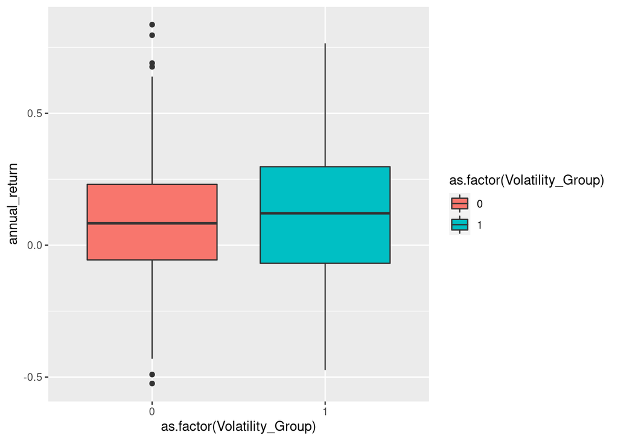

Here from the plot, I can say that the mean annual return of those shares whose volatility is below the average volatility is less compared to those having greater annual volatility than average. so here I can say there is a direct relationship between volatility and return of the share more the volatility max will be returning.

Next, I will do the same for volume to see the effect of volume in terms of annual returns of the share.

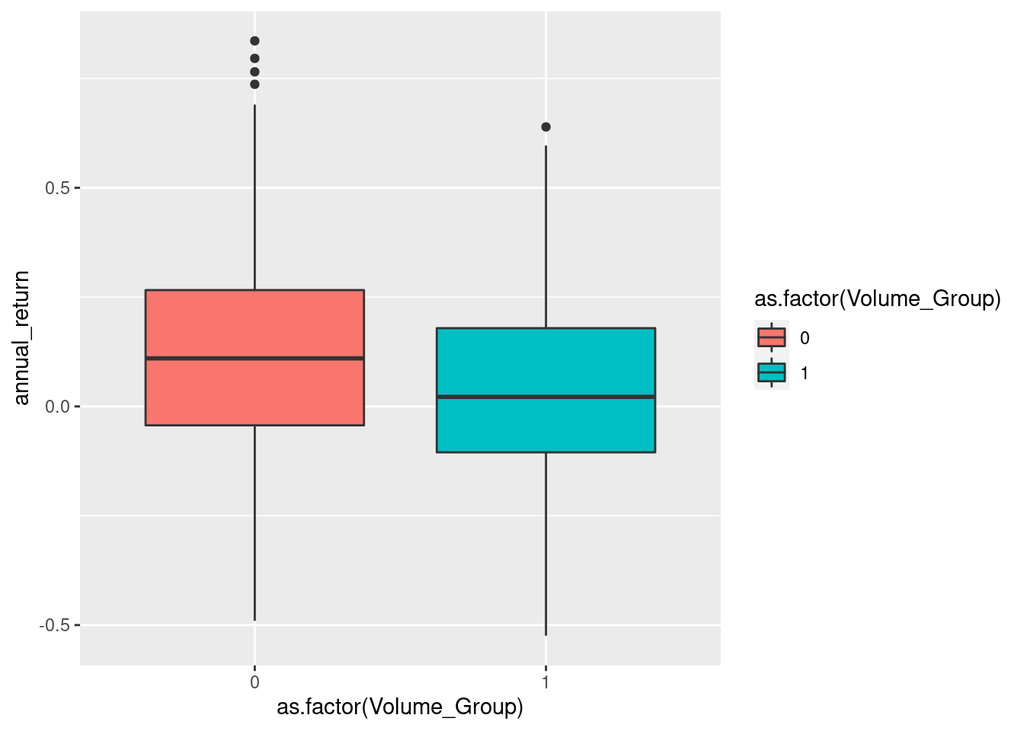

Here the relationship is opposite to the previous one because the shares whose share volume is less than annual volume earning more returns than those shares whose volume is more the annual volume, so lower the volume more is the return and vice versa.

#Task - 2

Next, to see the uncertainty effect of the stock market on the price, volatility, and return I will use the epudata dataset, I will use some plot and regression analysis to analyze the relationship between these factors. to calculate the annual volatility I will subtract the high price from the low price of each share. here are the first 6 rows of the EPU dataset.

```
##       ref.date FTSE.price.open FTSE.price.high FTSE.price.low FTSE.price.close
## 253 02/01/2001          6222.5          6276.2         6169.8           6174.7
## 254 03/01/2001          6174.7          6174.7         6029.3           6039.9
## 255 04/01/2001          6039.9          6195.3         6039.9           6185.6
## 256 05/01/2001          6185.6          6239.6         6155.0           6198.1
## 257 08/01/2001          6198.1          6212.4         6137.7           6149.6
## 258 09/01/2001          6149.6          6195.9         6066.4           6088.1
##     FTSE.volume FTSE.price.adjusted FTSE.ret.adjusted.prices    epu volatility
## 253   709054000              6174.7             -0.007681769 110.77  106.40039
## 254  1147114000              6039.9             -0.021831067 179.41  145.40039
## 255  1640397000              6185.6              0.024122949 183.22  155.39990
## 256  1293875000              6198.1              0.002020823  89.31   84.60010
## 257  1449404000              6149.6             -0.007824978 365.29   74.69971
## 258  1321566000              6088.1             -0.010000650 260.13  129.50000
```

Next i will use scatter plot with linear regression line to see the relation between economic polity uncertainty and price index, volatility and adjusted price of FTSE100 share.

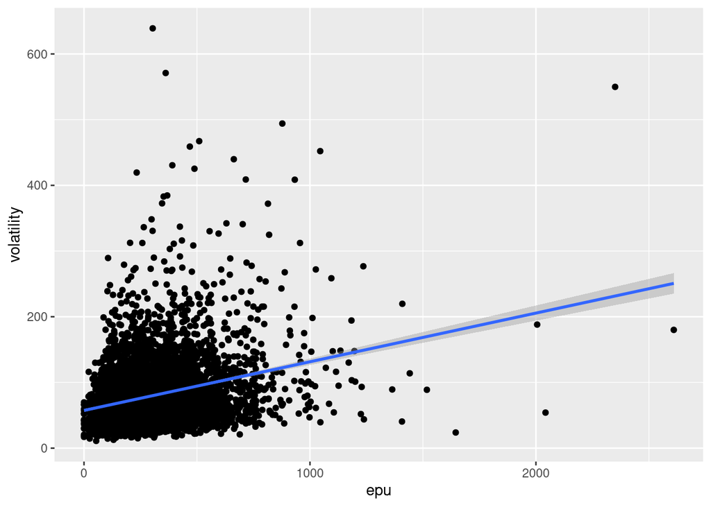

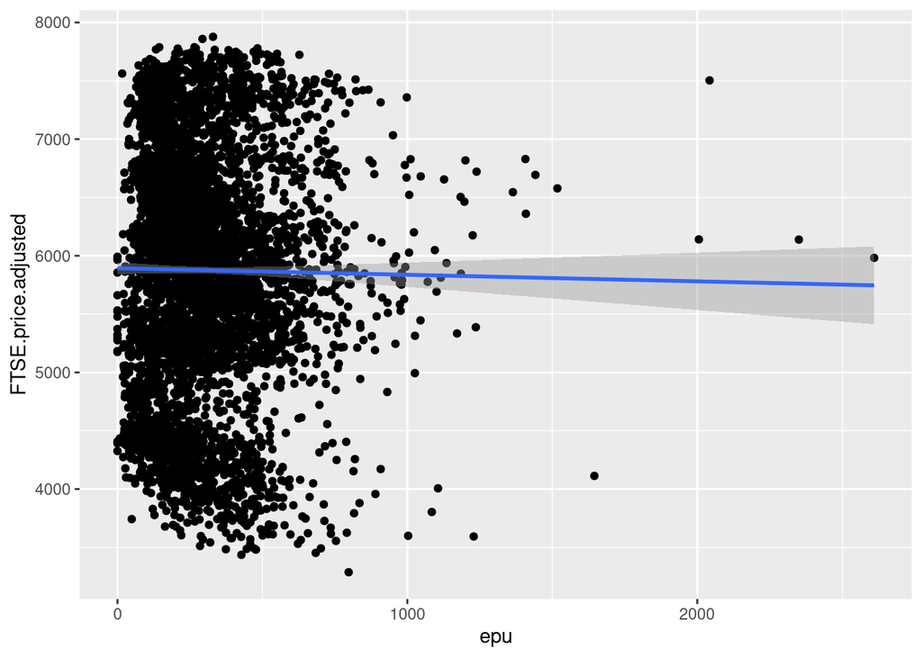

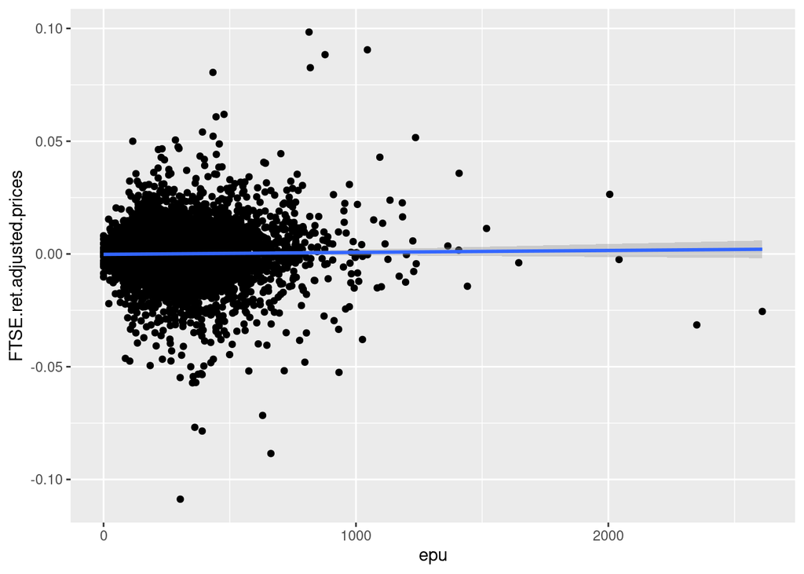

from the above three plot, I can say that volatility is having a direct relationship between the economic performance uncertainty because the slope is upward here, which means whenever the volatility increases the EPU also increase, but in case of price index and annual return, the slope is almost straight which shows that there is no relationship at all between this two factor with the economic performance uncertainty. Next, I will use a correlation plot to see the correlation value between these factors, this will give me a more depth analysis of the dependency of these variables between each other.

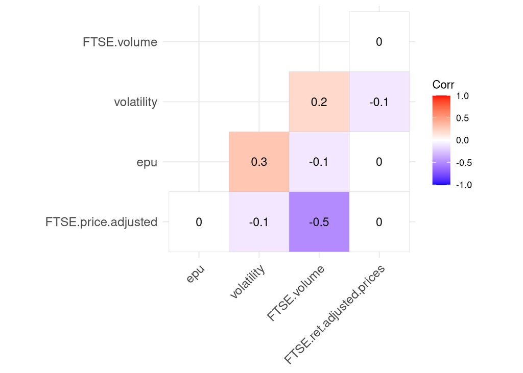

```
##
## Call:
## lm(formula = FTSE.ret.adjusted.prices ~ FTSE.price.adjusted +
##     FTSE.volume + volatility + FTSE.volume, data = EPU_data)
##
## Residuals:
##       Min        1Q    Median        3Q       Max
## -0.091821 -0.005823 -0.000621  0.005352  0.107279
##
## Coefficients:
##                       Estimate Std. Error t value Pr(>|t|)
## (Intercept)          2.343e-03  1.486e-03   1.577    0.115
## FTSE.price.adjusted  7.533e-08  1.960e-07   0.384    0.701
## FTSE.volume         -2.952e-13  4.234e-13  -0.697    0.486
## volatility          -2.974e-05  3.413e-06  -8.713   <2e-16 ***
## ---
## Signif. codes:  0 '***' 0.001 '**' 0.01 '*' 0.05 '.' 0.1 ' ' 1
##
## Residual standard error: 0.01191 on 5035 degrees of freedom
## Multiple R-squared:  0.01655,    Adjusted R-squared:  0.01597
## F-statistic: 28.25 on 3 and 5035 DF,  p-value: < 2.2e-16
```

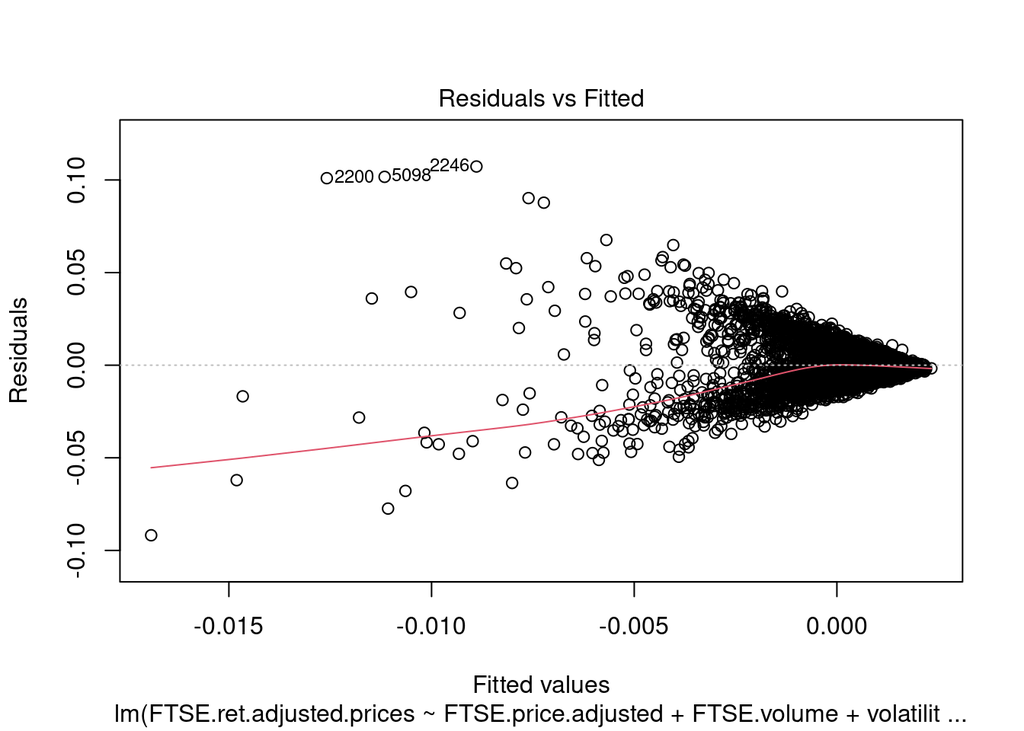

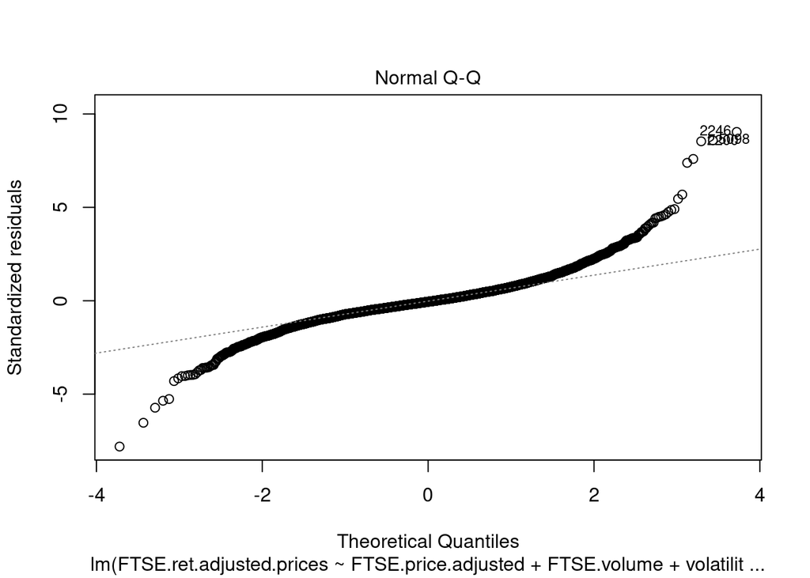

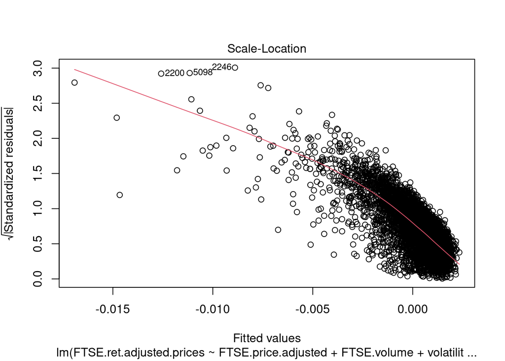

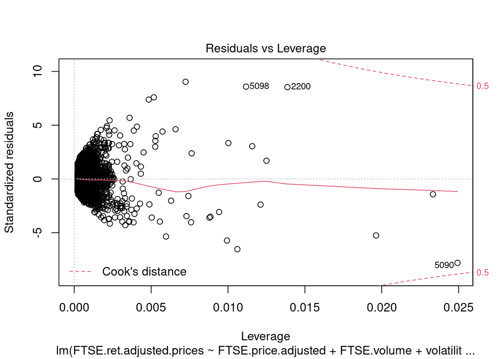

```
##
## ===================================
##                      Model 1
## -----------------------------------
## (Intercept)             0.00234
##                        (0.00149)
## FTSE.price.adjusted     0.00000
##                        (0.00000)
## FTSE.volume            -0.00000
##                        (0.00000)
## volatility             -0.00003 ***
##                        (0.00000)
## -----------------------------------
## R^2                     0.01655
## Adj. R^2                0.01597
## Num. obs.            5039
## ===================================
## *** p < 0.01; ** p < 0.05; * p < 0.1
```